# Some statistics

Psychologische Institut für psychologische Methodenlehre, Evaluation und Statistik

Carolina Fellinghauer

carolina.fellinghauer@uzh.ch

19 2 2020

# Rasch Analysis

- Rasch analysis is a modern test theory approach.
- Rasch is a probabilistic approach to measurement: the **probability of a response** is a **function** of the **ability** of the respondent and the **difficulty** of the item.
- The Rasch analysis tests if the responses to the questions also called items follow an expected pattern, called the **Guttmann pattern**.
- In Rasch analysis a series of assumptions are tested. If the data does not conform, than the data is adjusted (and not the model) to conform to the expectations of an instrument with metric properties.

## Guttman Pattern

The probability of a correct response is a function of the person’s ability.

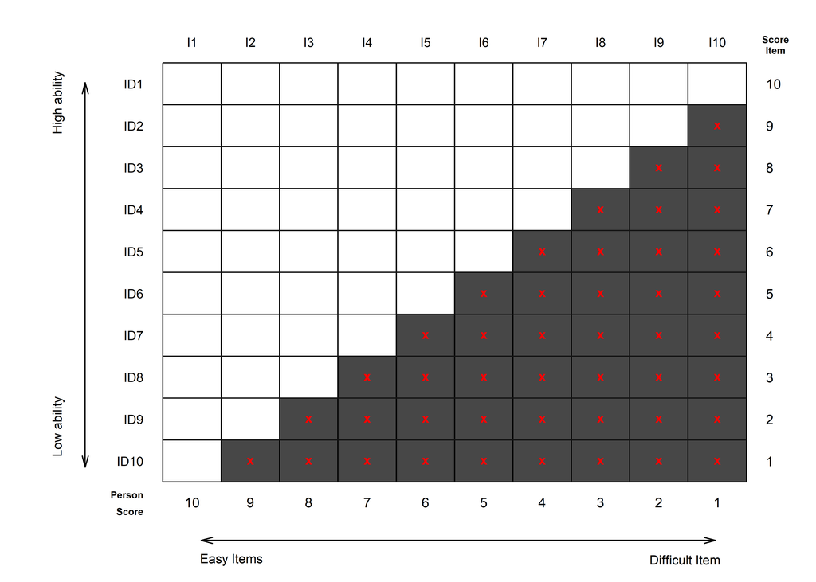

If the marginal scores, items and person, are sorted the Guttman pattern shows:

- the smaller the item score, the more difficult the item.
- the greater the person score, the more proficient the person.
- most persons with same total score show the same response pattern. For example: most persons with score of 5, should have responded the 5 easiest items correctly.
- However, beyond theory, data with perfect Guttman pattern is unlikely.

[figure not shown]

## General Rasch Formula

Dichotomous Rasch Model (Rasch 1960)

The probability of an correct response $x=1$ for a person $j$, on a particular item $i$ is written as a function of the $i^{th}$ item difficulty $\delta$ and the $j^{th}$ person’s ability $\theta$:

$$P(X_{ij} =1 | \theta_j) =
\frac{exp(\theta_j - \delta_i)}
{1 + exp(\theta_j - \delta_i)}$$

For random events with two outcomes (e.g. “success” or “failure”), the probability of “success” is formalized as $p$ and the probability of failure as $q = 1-p$. For the Rasch model, the probability of the response $x =0$, as alternative to $x = 1$ is then

$$P(X_{ij}=0) =
1 - \frac{exp(\theta_j - \delta_i)}
{1 + exp(\theta_j - \delta_i)} =
\frac{1}
{1 + exp (\theta_j - \delta_i)}$$

For example: the probability that a person with a proficiency of $\theta = 5$ responds correctly to an item with difficulty $\theta = 6$ is

$$P(X_{ij}=1) =
\frac{e^{5 - 6}}
{1 + e^{5 - 6}} =
\frac{e^{-1}}
{1 + e^{-1}} = 0.26$$

- What is the probability that the person responds $X=0$?
- What happens if the person’s ability equals the item difficulty?

## Family of Rasch and IRT Models: Overview

A simplified view, on how Rasch and IRT relate is shown in the tree below. Note that, the specialist of the field themselves do not totally agree on the similarity and boundaries between some of the models.

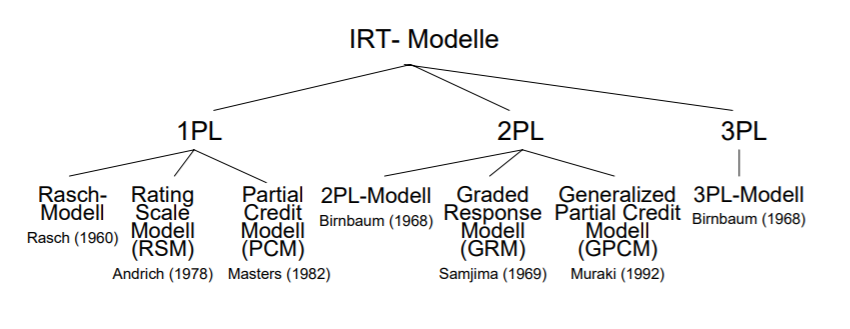

All Rasch models have in common that the item discrimination or the slope of the item characteristic curve (ICC), is a fix parameter which does not vary across items.

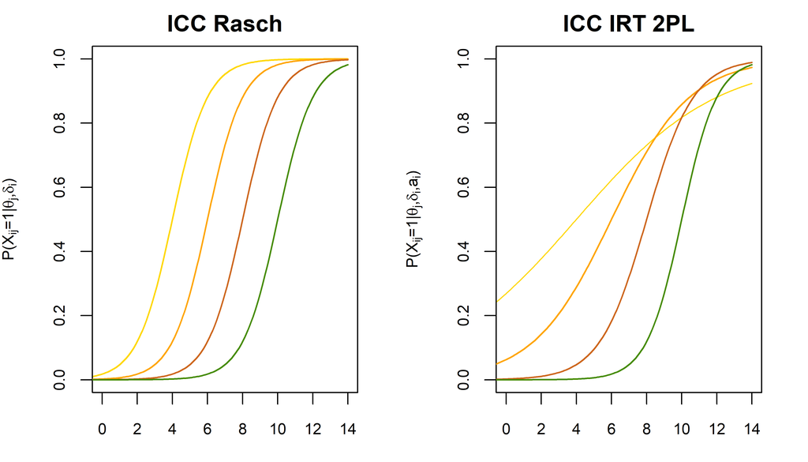

### Rasch Models

**Rasch Model** (RM) for dichotomous responses needs only two parameters to describe performance on the latent trait: the item difficulty ($\delta$) and the person ability ($\theta$).

**Rating Scale Model** (RSM) from (Andrich 2011) includes additionally a threshold parameter ($\lambda$) to calibrate assessment instruments with polytomous response options. The thresholds are set to be equidistant across items with identical number of response options.

**Partial Credit Model** (PCM) from (Masters 1982) is an extension of the RSM where thresholds are not forced to be equidistant and items can have different number of response options.

### IRT Models

The IRT models start with the Rasch parameterisation and include additional parameters.

**1-Parameter Logistic Model** (1-PL) is similar to the Rasch model as it has only one parameter to estimate the model: the item difficulty

**2-Parameter Logistic Models** (2-PL) are an extension of the 1-PL model as it allows the items to have different item discrimination. Contrary to the Rasch models and the 1-PL model, persons with same item score can have different ability estimates, e.g. when one of the persons (with same score) has responded correctly to more difficult items.

**3-Parameter Logistic** (3-PL) is a further extension where a guession parameter is added to the model.

**4-Parameter Logistic** (4-PL) a further extension which accommodates for carelessness mistakes in high ability respondents.

## Family of Rasch/IRT Models: Formulas

### Logic of Rasch models in formulas

**Dichotomous Rasch Model**

$$P(X_{ij} =1 | \theta_j) =
\frac{exp(\theta_j - \delta_i)}
{1 + exp(\theta_j - \delta_i)}$$

**Ratings Scale Model** (RSM) Andrich (1978)

RSM model is a Rasch model for polytomous response options. Threshold parameter can be split into location and response threshold (shift) :

$$\delta_{ik} = \delta_i + \lambda_k$$

The shift in difficulty when responding category $k=2$ or $k=1$, is equal to $\delta_{i2} - \delta_{i1}$ **for all the items** of the scale. In fact, the item difficulties ($\delta$) can vary but not deviations ($\lambda$) for the response options ($k$), which are the same across the items. The probability of a response becomes:

$$P(X_{ikj}=1 | \theta_j) =
\frac{exp{(\theta_j - \delta_{ik})}}
{\Sigma^{m_i}_{c=0} exp \Sigma_{h=0}^{c} (\theta_j - \delta_{ik})}$$

**Partial Credit Model** (PCM) Masters (1982)

The PCM is also a Rasch model for polytomous response options. The formula is very similar to the RSM formula. However, $\delta_{ik}$ the threshold parameter consists of the item location ($\delta_i$) and an **item specific** response category deviation parameter ($\lambda_{ik}$).

$$\delta_{ik} = \delta_i + \lambda_{ik}$$
$X_{ikj}$ is the $j^{th}$ person’s response in category $k$, with $m_i + 1$ possible options, to the $i^{th}$ item. Its probability is expressed with:

$$P(X_{ikj} = k | \theta_j) =
\frac{exp{(\theta_j - \delta_{ik})}}
{\Sigma^{m_i}_{c=0} exp \Sigma_{h=0}^{c} (\theta_j - \delta_{ik})}$$

### Logic of IRT models in formulas

**One-Parameter Logistic Model** (1-PL)

1-PL is a special case of the 2-PL model with the slope parameter constrained to be the same across items. Despite striking similarities, it is often not considered identical to the Rasch model.

$$P(X_{ij} = 1 | \theta_j) =
\frac{exp [a(\theta_j - \delta_{i})]}
{1 + exp[a(\theta_j - \delta_{i})]}$$

**Two-Parameter Logistic Model** (2-PL)

2-PL is an extension of the 1-PL with an additional parameter *a* for the discrimination of $i^{th}$ item.

- **Graded Response Model** (GRM) (Samejima 1969)

The GRM is a widely known IRT model. The GRM uses a cumulative category response function and has one additional parameter, $a_i$, corresponding to the $i^{th}$ item slope, so called discrimination parameter.

$$P(X_{ij} = 1 | \theta_j) =
\frac{exp [a_i(\theta_j - \delta_{i})]}
{1 + exp[a_i(\theta_j - \delta_{i})]}$$

- **Generalized Partial Credit Model** (GPCM) (Muraki 1992)

The GPCM is an extension of the PCM model (and so also of the RSM) with itemwise unconstrained slope parameter, i.e. with an additional parameter for the item discrimination $a_i$. It uses a score category response function to estimate the probability of a response $X_{ijk}$ and is formalized as:

$$P(X_{ikj}= k | \theta_j) =
\frac{exp \Sigma_{h=0}^k a_i(\theta_j - \delta_{ik})}
{ \Sigma^{m_i}_{c=0} exp \Sigma_{h=0}^{c}[a_i(\theta_j - \delta_{ik})]}$$

or parameterized with location ($\delta$) plus deviation ($\lambda$):

$$P(X_{ikj} = k | \theta_j) =
\frac{exp \Sigma_{h=0}^k a_i(\theta_j - \delta_{i} + \lambda_{ik})}
{\Sigma^{m_i}_{c=0} exp \Sigma_{h=0}^{c}[a_i(\theta_j - \delta_{i} + \lambda_{ik})]}$$

**Three-Parameter Logistic Model** (3-PL) (Birnbaum 1968)

The 3-PL adds a third parameter to the 2-PL model. The letter $g$ represents parameter for response *guessing*. Under this model, persons with zero ability have still a chance of endorsing an item, by guessing randomly. How much guessing is expected can vary from item to item and is formalized as:

$$P(X_{ij} = 1 | \theta_j) = g_i + (1-g_i)
\frac{exp[ a_i(\theta_j - \delta_{i})]}
{1 + exp[a_i(\theta_j - \delta_i)]}$$

**Four-Parameter Logistic Model** (4-PL) (Barton and Lord 1981)

The 4-PL model adds a “slip” parameter, or upper asymptote, designed to accommodate high ability respondent’s carelessness mistakes and is formalized as follows:

$$P(X_{ij} = 1 | \theta_j) = g_i + (u_i - g_i)
\frac{exp[ a_i(\theta_j - \delta_{i})]}
{1 + exp[a_i(\theta_j - \delta_i)]}$$

The notation is similar to the 3-PL model, with the addition of the parameter $u_i$.

## Rasch Analysis in Practice

Rasch analysis is frequently applied to test if an instrument shows important (psycho)metric properties.

- Stochastic ordering (fit of data to model)
- Monotonicity (ordering or response options)
- No local response dependencies or LID (no significant correlations between items)
- No differential item functioning or DIF (no sample subgroup effects)
- Unidimensionality (one latent construct)

The Rasch assumptions are tested iteratively while the assessment instrument is adjusted stepwise until all breaches to the Rasch assumptions are fixed.

# R Packages

This course will use following R-packages to perform the Rasch analyses.

Main focus of the course is on the testing of psychometric assumptions with the Rasch model with the package `eRm` from (Mair, Hatzinger, and Maier 2019), technical details and references regarding the package and the functions it contains are found in R when typing `vignette("eRm")`.

The R-package `mirt`(Chalmers 2012) will be shown to illustrate multidimensional analyses as well as test equating and computer adaptive testing.

The R-package `psych` (Revelle 2019) contains various functions to simulate different type of psychometric data.

The R packages `iarm` (Mueller 2020) contains useful function for Rasch analysis.

# Dichotomous Rasch Analysis

The most common Rasch model is the model for dichotomously rated items.

```r
# call the eRm library
library(eRm)
```

```r
# simulate 10 dichotomous items for 500 persons
Data_Dicho <- sim.rasch(500, 10, seed = 1234)

RM_Dicho <- RM(Data_Dicho)

print(summary(RM_Dicho))
```

```
##
## Results of RM estimation:
##
## Call:  RM(X = Data_Dicho)
##
## Conditional log-likelihood: -1807.416
## Number of iterations: 17
## Number of parameters: 9
##
## Item (Category) Difficulty Parameters (eta): with 0.95 CI:
##     Estimate Std. Error lower CI upper CI
## I2     0.632      0.096    0.444    0.820
## I3     1.437      0.105    1.232    1.642
## I4    -2.296      0.154   -2.598   -1.994
## I5     0.945      0.098    0.752    1.138
## I6     1.007      0.099    0.814    1.201
## I7    -0.300      0.098   -0.491   -0.108
## I8    -0.046      0.096   -0.234    0.142
## I9    -0.146      0.097   -0.336    0.043
## I10   -0.404      0.099   -0.598   -0.211
##
## Item Easiness Parameters (beta) with 0.95 CI:
##          Estimate Std. Error lower CI upper CI
## beta I1     0.830      0.105    0.625    1.035
## beta I2    -0.632      0.096   -0.820   -0.444
## beta I3    -1.437      0.105   -1.642   -1.232
## beta I4     2.296      0.154    1.994    2.598
## beta I5    -0.945      0.098   -1.138   -0.752
## beta I6    -1.007      0.099   -1.201   -0.814
## beta I7     0.300      0.098    0.108    0.491
## beta I8     0.046      0.096   -0.142    0.234
## beta I9     0.146      0.097   -0.043    0.336
## beta I10    0.404      0.099    0.211    0.598
##
## NULL
```

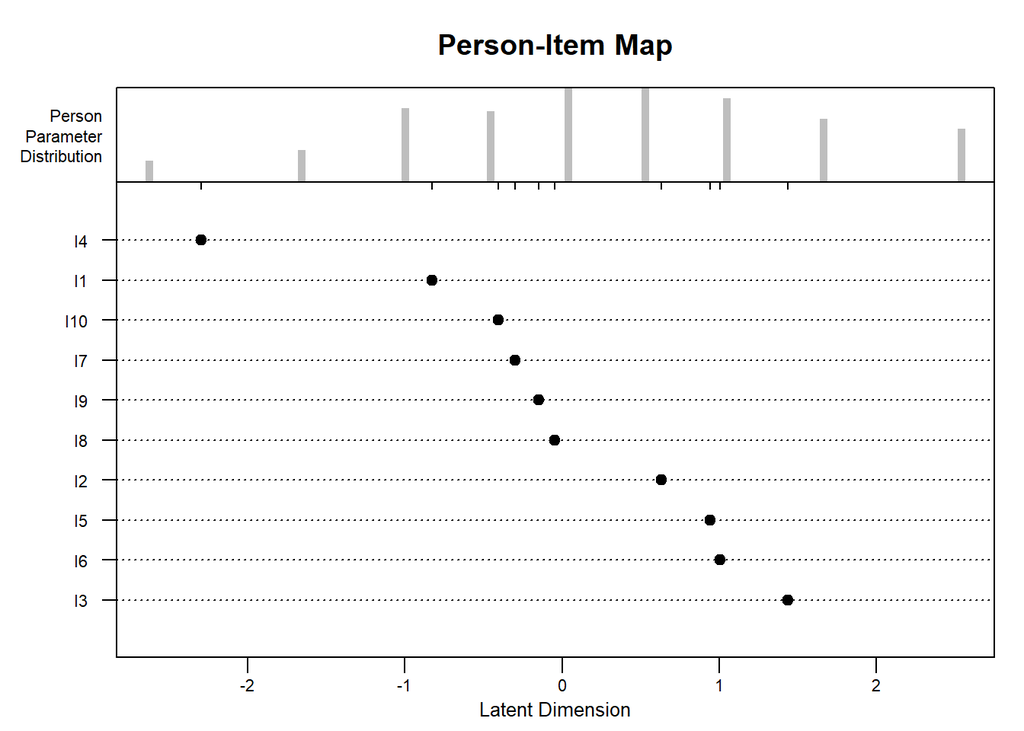

```r
plotPImap(RM_Dicho, sorted = TRUE)  #shows the item difficulty increasingly
```

# Polytomous Rasch Analysis

Two models from the ‘Rasch family’ can deal with polytomous response options: the rating scale model (RSM) and the partial credit model (PCM).

The RSM assumes equidistant difficulty thresholds across items, the PCM does not constrain the difficulty thresholds.

First, we simulate polytomous data.

```r
library(psych)  #package for data simulation

## function for gpcm but with always same constraint on slopes for Rasch simulates
## 8 items and 500 observations


## threshold simulation
set.seed(9876)  # reproducibility
Data_Poly <- sim.poly.npl(nvar = 8, n = 500, low = -4, high = 4, a = rep(1, 8), c = 0,
    z = 1, d = NULL, mu = 0, sd = 1.96, cat = 3)$items
```

## Rating Scale Model

```r
RSM_Poly <- RSM(Data_Poly)
summary(RSM_Poly)
```

```
##
## Results of RSM estimation:
##
## Call:  RSM(X = Data_Poly)
##
## Conditional log-likelihood: -1160.304
## Number of iterations: 22
## Number of parameters: 8
##
## Item (Category) Difficulty Parameters (eta): with 0.95 CI:
##       Estimate Std. Error lower CI upper CI
## V2      -3.039      0.136   -3.306   -2.773
## V3      -1.794      0.103   -1.995   -1.592
## V4      -0.660      0.087   -0.831   -0.488
## V5       0.552      0.088    0.379    0.725
## V6       1.860      0.109    1.647    2.074
## V7       3.024      0.142    2.745    3.302
## V8       3.995      0.181    3.640    4.349
## Cat 2    1.490      0.125    1.244    1.735
##
## Item Easiness Parameters (beta) with 0.95 CI:
##            Estimate Std. Error lower CI upper CI
## beta V1.c1    3.938      0.170    3.604    4.272
## beta V1.c2    6.387      0.293    5.813    6.960
## beta V2.c1    3.039      0.136    2.773    3.306
## beta V2.c2    4.589      0.232    4.135    5.043
## beta V3.c1    1.794      0.103    1.592    1.995
## beta V3.c2    2.098      0.193    1.720    2.475
## beta V4.c1    0.660      0.087    0.488    0.831
## beta V4.c2   -0.170      0.196   -0.554    0.214
## beta V5.c1   -0.552      0.088   -0.725   -0.379
## beta V5.c2   -2.593      0.233   -3.050   -2.135
## beta V6.c1   -1.860      0.109   -2.074   -1.647
## beta V6.c2   -5.210      0.292   -5.783   -4.638
## beta V7.c1   -3.024      0.142   -3.302   -2.745
## beta V7.c2   -7.537      0.363   -8.249   -6.825
## beta V8.c1   -3.995      0.181   -4.349   -3.640
## beta V8.c2   -9.479      0.438  -10.338   -8.620
```

## Partial Credit Model

```r
PCM_Poly <- PCM(Data_Poly)
summary(PCM_Poly)
```

```
##
## Results of PCM estimation:
##
## Call:  PCM(X = Data_Poly)
##
## Conditional log-likelihood: -1154.912
## Number of iterations: 33
## Number of parameters: 15
##
## Item (Category) Difficulty Parameters (eta): with 0.95 CI:
##       Estimate Std. Error lower CI upper CI
## V1.c2   -6.931      0.360   -7.637   -6.225
## V2.c1   -3.714      0.283   -4.268   -3.159
## V2.c2   -5.785      0.290   -6.353   -5.217
## V3.c1   -2.392      0.184   -2.753   -2.030
## V3.c2   -3.249      0.214   -3.668   -2.830
## V4.c1   -1.253      0.151   -1.549   -0.957
## V4.c2   -0.979      0.198   -1.367   -0.590
## V5.c1    0.119      0.141   -0.157    0.394
## V5.c2    1.389      0.210    0.978    1.801
## V6.c1    1.146      0.141    0.869    1.424
## V6.c2    4.236      0.260    3.726    4.745
## V7.c1    2.456      0.166    2.130    2.782
## V7.c2    6.519      0.353    5.826    7.212
## V8.c1    3.376      0.195    2.993    3.759
## V8.c2    8.778      0.533    7.733    9.824
##
## Item Easiness Parameters (beta) with 0.95 CI:
##            Estimate Std. Error lower CI upper CI
## beta V1.c1    3.718      0.367    2.999    4.438
## beta V1.c2    6.931      0.360    6.225    7.637
## beta V2.c1    3.714      0.283    3.159    4.268
## beta V2.c2    5.785      0.290    5.217    6.353
## beta V3.c1    2.392      0.184    2.030    2.753
## beta V3.c2    3.249      0.214    2.830    3.668
## beta V4.c1    1.253      0.151    0.957    1.549
## beta V4.c2    0.979      0.198    0.590    1.367
## beta V5.c1   -0.119      0.141   -0.394    0.157
## beta V5.c2   -1.389      0.210   -1.801   -0.978
## beta V6.c1   -1.146      0.141   -1.424   -0.869
## beta V6.c2   -4.236      0.260   -4.745   -3.726
## beta V7.c1   -2.456      0.166   -2.782   -2.130
## beta V7.c2   -6.519      0.353   -7.212   -5.826
## beta V8.c1   -3.376      0.195   -3.759   -2.993
## beta V8.c2   -8.778      0.533   -9.824   -7.733
```

The following threshold maps for the RSM and PCM model illustrate the different manners to formalize threshold estimation in presence of data with polytomous responses.

The function `ThresholdMap` is found in the `R2R` package, that may or may not be part of R yet. It contains useful functions for Rasch analysis with `R` that are not found in other packages.

If necessary, let’s first install the zip of the package.

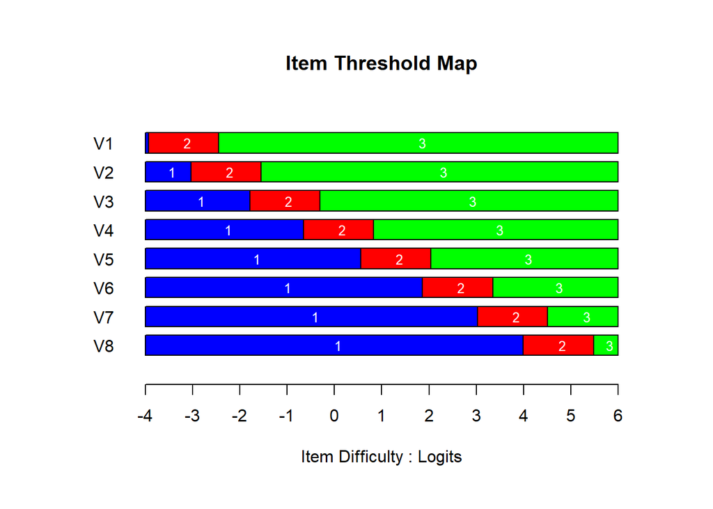

```r
# ThresholdMap requires installation of R2R
library(R2R)


ThresholdMap(thresholds(RSM_Poly))
```

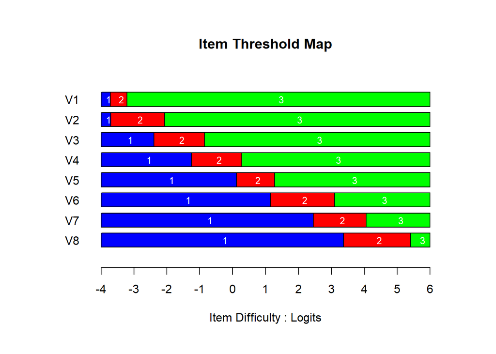

```r
ThresholdMap(thresholds(PCM_Poly))
```

### Model comparison

The RSM is the less complex model using less parameter for estimation. It is generally recommended to test first if the data may fit this model instead of the PCM, if all items are polytomous with the same number of response options.

One way to compare the RSM and PCM model is to apply a statistical test to determine which formula fits best to the data. A well-known statistical test procedure for the comparison of nested models is the likelihood ratio test. Nested means that one model formula is more constrained (RSM) or nested in the less constrained model (PCM). Here, the nested models are also called the reduced (RSM) and the full (PCM) model. The likelihood ratio test is conducted using the `anova()` function, entering first the reduced than the full model.

The `anova` tests the null hypothesis that the RSM fits the data better, the alternative hypothesis that the PCM, the full model has a better fit. If the p-value is significant, i.e. $< 0.05$, the null hypothesis can be rejected, meaning that there is a significant improvement in model fit when using the PCM.

Which model would we chose here?

```r
anova(RSM_Poly, PCM_Poly)
```

[output not shown]

# Exercise

Create a random sample of polytomous data with item discrimination constraint, for N = 500 persons and 15 items with 4 response categories, with difficulties ranging from -6 to 6 using `sim.poly.npl`.

Test which Rasch model fits the data better.

Please use `set.seed(2020)`for the random sampling and make sure that the results are invariant.

## References

Andrich, D. 2011. “Rating Scales and Rasch Measurement.” *Expert Rev Pharmacoecon Outcomes Res* 11 (5): 571–85. https://doi.org/10.1586/erp.11.59.

Barton, Mark A., and Frederic M. Lord. 1981. “An Upper Asymptote for the Three-Parameter Logistic Item-Response Model.” *ETS Research Report Series* 1981 (1): i–8. https://doi.org/10.1002/j.2333-8504.1981.tb01255.x.

Birnbaum, A. 1968. “Some Latent Trait Models and Their Use in Inferring an Examinee’s Ability.” In *Statistical Theories of Mental Test Scores*, edited by F. M. Lord and M. R. Novick, 397–479. Addison-Wesley, Reading.

Chalmers, R. Philip. 2012. “mirt: A Multidimensional Item Response Theory Package for the R Environment.” *Journal of Statistical Software* 48 (6): 1–29. https://doi.org/10.18637/jss.v048.i06.

Mair, Patrick, Reinhold Hatzinger, and Marco Johannes Maier. 2019. *eRm: Extended Rasch Modeling*.

Masters, Geoff N. 1982. “A Rasch Model for Partial Credit Scoring.” *Psychometrika* 47 (June): 149–74.

Mueller, Marianne. 2020. *Iarm: Item Analysis in Rasch Models*. https://CRAN.R-project.org/package=iarm.

Muraki, Eiji. 1992. “A Generalized Partial Credit Model: Application of an Em Algorithm.” *Applied Psychological Measurement* 16 (2): 159–76. https://doi.org/10.1177/014662169201600206.

Rasch, G. 1960. *Probabilistic Models for Some Intelligence and Attainment Tests*. Copenhagen: [s.n.].

Revelle, William. 2019. *Psych: Procedures for Psychological, Psychometric, and Personality Research*. Evanston, Illinois: Northwestern University.

Samejima, Fumiko. 1969. “Estimation of Latent Ability Using a Response Pattern of Graded Scores.” *Psychometrika* 34 (1): 1–97. https://doi.org/10.1007/BF03372160.